# HW 2: From correlation to linear mixed-effect models. Assignment sheet

## 1. Vowel reduction in Russian

Pavel Duryagin ran an experiment on perception of vowel reduction in Russian language. The dataset `shva` includes the following variables:  
*time1* - reaction time 1  
*duration* - duration of the vowel in the stimuly (in milliseconds, ms)  
*time2* - reaction time 2  
*f1*, *f2*, *f3* - the 1st, 2nd and 3rd formant of the vowel measured in Hz (for a short introduction into formants, see [here](https://home.cc.umanitoba.ca/~krussll/phonetics/acoustic/formants.html))  
*vowel* - vowel classified according the 3-fold classification (*A* - *a* under stress, *a* - *a/o* as in the first syllable before the stressed one, *y* (stands for shva) - *a/o* as in the second etc. syllable before the stressed one or after the stressed syllable, cf. *g*[*y*]*g*[*a*]*t*[*A*]*l*[*y*] *gogotala* `guffawed’).  
In this part, we will ask you to analyse correlation between f1, f2, and duration. The dataset is available https://raw.githubusercontent.com/agricolamz/2018-MAG_R_course/master/data/duryagin_ReductionRussian.txt.

### 1.0 Read the data from file to the variable `shva`.

```r
shva <- read.csv('duryagin_ReductionRussian.txt', sep = '\t')
```

### 1.1 Scatterplot `f1` and `f2` using `ggplot()`.

Design it to look like the [following](https://raw.githubusercontent.com/agricolamz/2018-MAG_R_course/master/img/duryagin1.png).

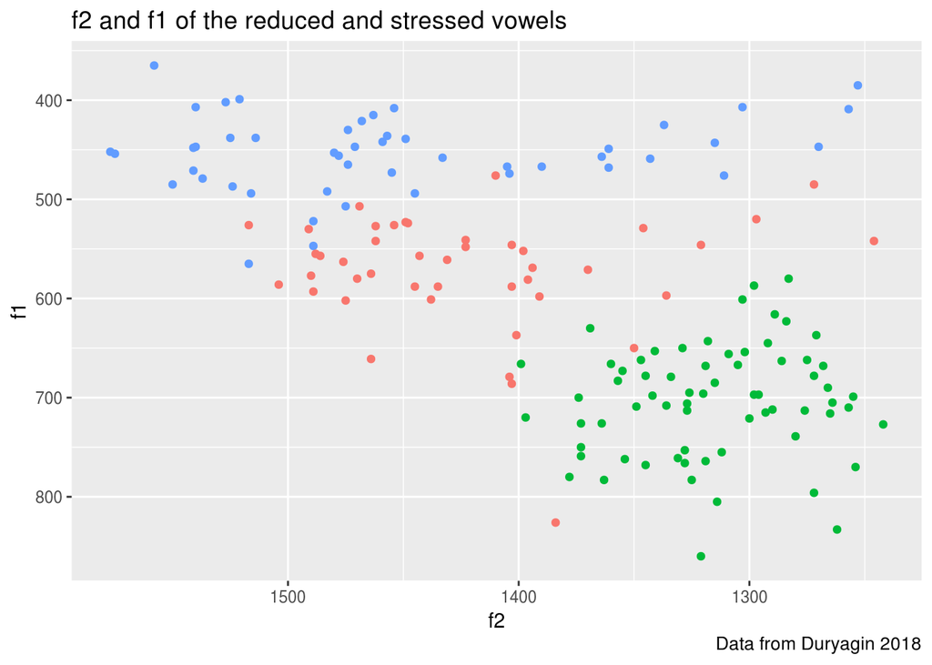

```r
shva %>%
  ggplot(aes(f2, f1)) +
  geom_point(aes(colour=factor(vowel)), show.legend = F) +
  scale_y_reverse() +
  scale_x_reverse() +
  labs(title='f2 and f1 of the reduced and stressed vowels', caption="Data from Duryagin 2018")
```

### 1.2 Plot the boxplots of `f1` and `f2` for each vowel using `ggplot()`.

Design it to look like [this](https://raw.githubusercontent.com/agricolamz/2018-MAG_R_course/master/img/duryagin2.png) and [this](https://raw.githubusercontent.com/agricolamz/2018-MAG_R_course/master/img/duryagin3.png).

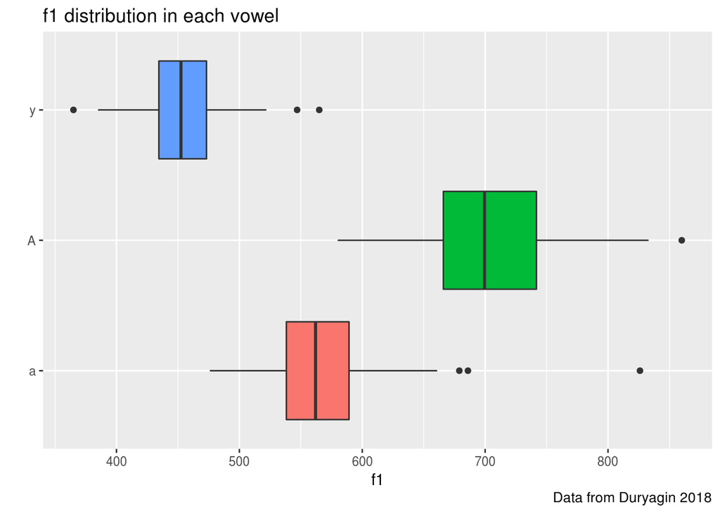

```r
# f1 boxplot
shva %>%
  ggplot(aes(vowel, f1, fill=vowel)) +
  geom_boxplot(show.legend = F) +
  coord_flip() +
  xlab('') +
  labs(title = 'f1 distribution in each vowel', caption = 'Data from Duryagin 2018')
```

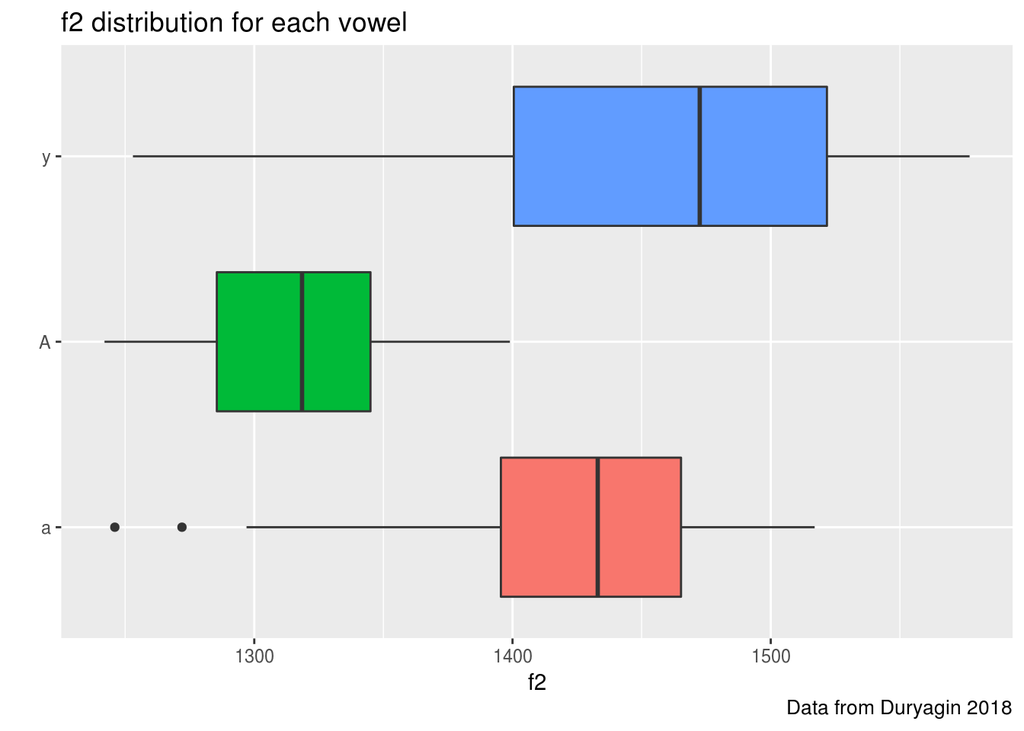

```r
# f2 boxplot

shva %>%
  ggplot(aes(vowel, f2, fill=vowel)) +
  geom_boxplot(show.legend = F) +
  coord_flip() +
  xlab('') +
  labs(title = 'f2 distribution for each vowel', caption = "Data from Duryagin 2018")
```

We assume outliers to be those observations that lie outside 1.5 * IQR, where IQR, the ‘Inter Quartile Range’, is the difference between the 1st and the 3rd quartile (= 25% and 75% percentile).

### 1.4 Calculate Pearson’s correlation of `f1` and `f2` (all data)

```r
cor(shva$f1, shva$f2, method='pearson')
```

```
## [1] -0.5797475
```

### 1.5 Calculate Pearson’s correlation of `f1` and `f2` for each vowel

```r
cor(shva[shva$vowel=='a',]$f1, shva[shva$vowel=='a',]$f2)
```

```
## [1] -0.01126545
```

```r
cor(shva[shva$vowel=='y',]$f1, shva[shva$vowel=='y',]$f2)
```

```
## [1] 0.181871
```

```r
cor(shva[shva$vowel=='A',]$f1, shva[shva$vowel=='A',]$f2)
```

```
## [1] 0.1032741
```